# Liberating tabular data from the clutches of PDFs

By: Jayant Pahuja & Spongebob  
Data Expert @OpenBudgetsIndia  
Core Team Member @DataKindBlR

## Budgets

- Why are budgets important ?
- What kind of data is published ?
- How are they published ?

### 150+ Budget Source Websites

[figure not shown]

```python
Image('govt_budget_portals.png')
```

## Problems with Budget Documents

- Unstructured PDF documents
- Inconsistent Formats
- Budgets published in local languages

[figure not shown]

```python
Image('whaat.jpg')
```

## Karnataka Budget

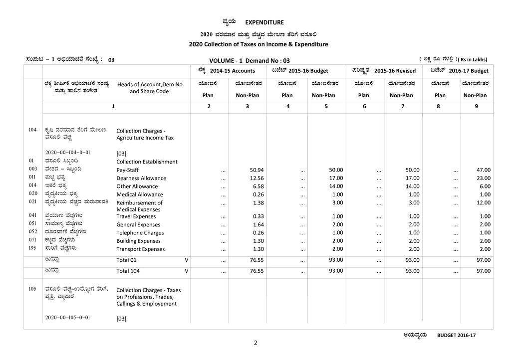

```python
Image('kn_sample_image.png')
```

## West Bengal Budget

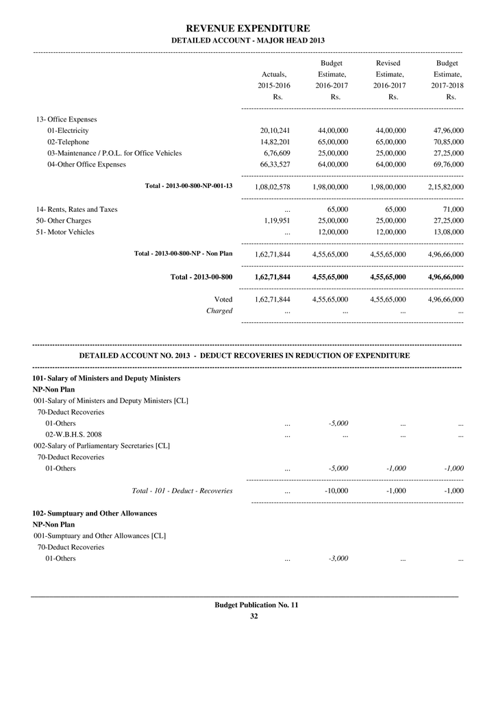

```python
Image('west_bengal_sample.png')
```

## Gujarat Budget

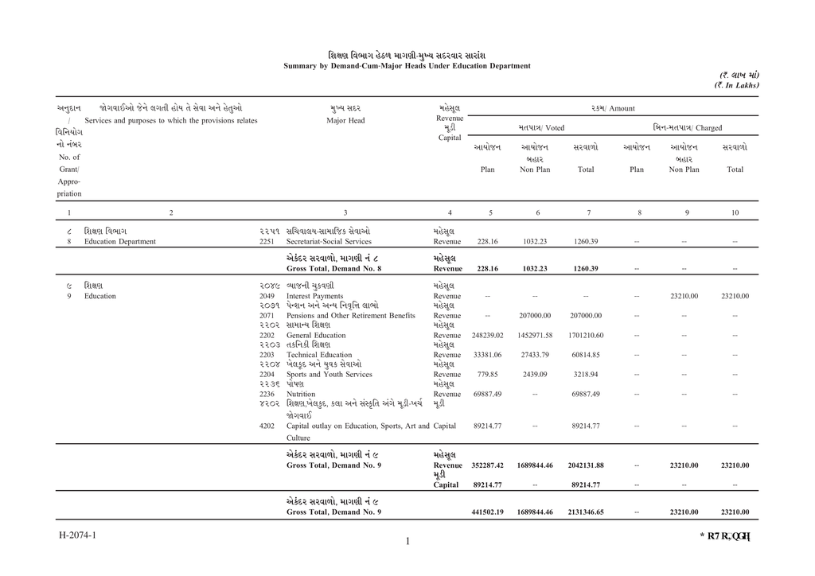

```python
Image('gj_sample_image.png')
```

## Categories of Budget Documents

### Documents with Table Boundaries

- Karnataka Budget Documents

### Documents without Table Boundaries

- West Bengal
- Gujarat

## Extracting Tables From Documents with Table Boundaries

**Concept**: Detect Rows and Columns based on the lines detected and parse the infromation to extract tables in csv format.

- Detect Lines
  - Vertical
  - Horizontal
- Detect Table Boundaries
- Parse Tables To extract information in csv format.

## Converting Pdf Page To Image - I

```python
import cv2
import subprocess

# Converting a pdf page into an Image for processing
def get_page_image_from_pdf(page_num, image_file_name, pdf_file_path):
    '''
    Convert a pdf page into an image using imagemagick's convert utility
    '''
    command = "convert -density 300 '%s'[%s] '%s'" % (pdf_file_path,
                                                      page_num,
                                                      image_file_name)
    subprocess.check_output(command, shell=True)
    return cv2.imread(image_file_name, 0)
```

## Converting Pdf Page To Image - II

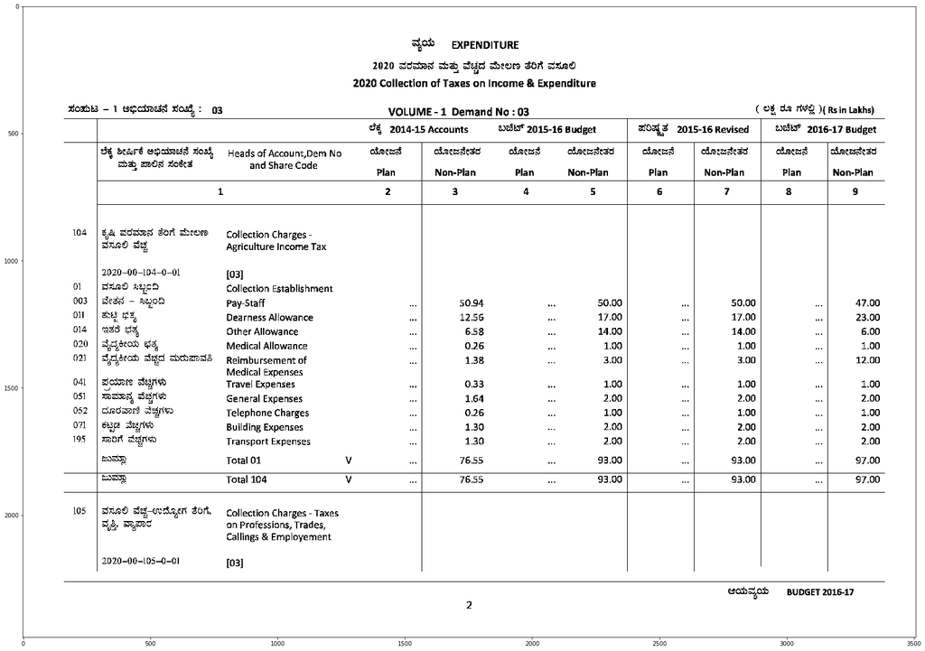

```python
kn_page_image = get_page_image_from_pdf(11, 'kn_sample_image.png', kn_pdf_file_path)
plt.figure(figsize=(30,20))
plt.imshow(kn_page_image, cmap='gray')
```

### Detecting Lines

To detect lines we use openCV's Hough Transform Implementation

```
cv2.HoughLines(), cv2.HoughLinesP()
```

[figure not shown]

```python
Image('lines.jpg')
```

## Extracting Edges

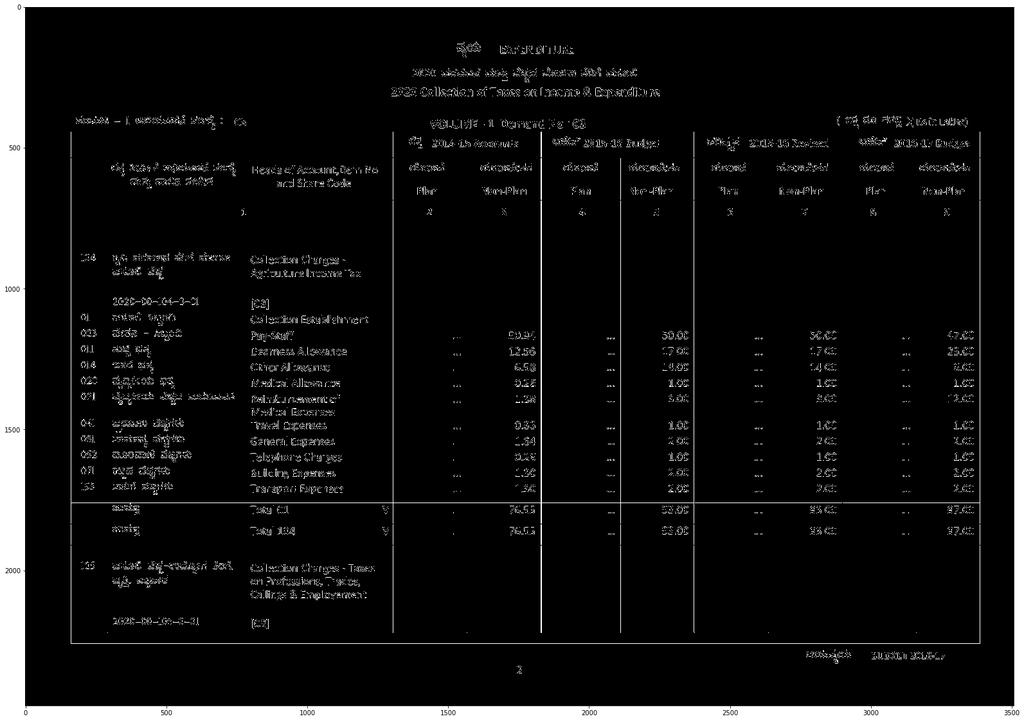

```python
edges = cv2.Canny(kn_page_image, 120, 150, apertureSize=3)
plot_page(edges)
```

## Detecting Lines From Edges - Hough Transform

```python
lines = cv2.HoughLines(edges,1,np.pi/180,200)
lines[:5]
```

```
array([[[  4.42000000e+02,   1.57079637e+00]],

       [[  2.26000000e+03,   1.57079637e+00]],

       [[  5.35000000e+02,   1.57079637e+00]],

       [[  1.76000000e+03,   1.57079637e+00]],

       [[  1.83500000e+03,   1.57079637e+00]]], dtype=float32)
```

```python
HTML('<img src="http://opencv-python-tutroals.readthedocs.io/en/latest/_images/houghlinesdemo.gif">')
```

[figure not shown]

## Detecting Straight Lines

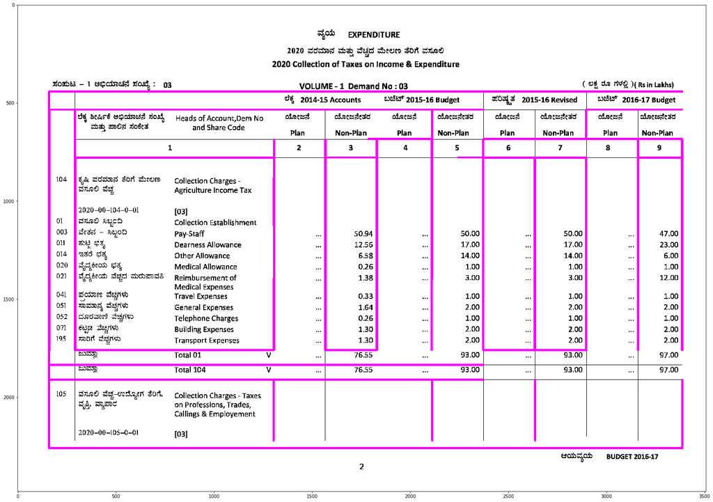

```python
def get_straight_lines(img, aperture_size=3):
    '''Extract long straight lines using Probabilistic Hough Transform
    '''
    edges = cv2.Canny(img, 120, 150, apertureSize=aperture_size)
    min_line_length = 100
    max_line_gap = 100
    lines = cv2.HoughLinesP(edges, 1, np.pi/180, 80, min_line_length,
                            max_line_gap)
    return lines


lines = get_straight_lines(kn_page_image)
plot_lines_on_image(lines, kn_page_image)
```

## Extending Lines To Table Boundaries

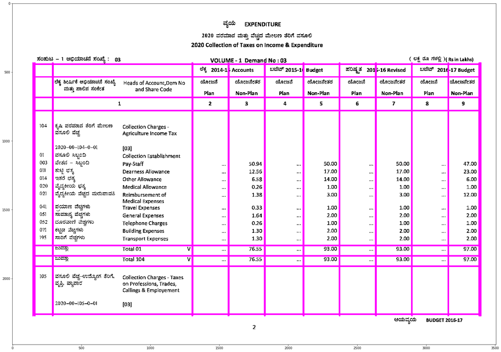

```python
table_limits = get_table_limits(kn_page_image, lines, False)
plot_page(extend_lines_for_table(kn_page_image, lines, False, table_limits))
```

## Parsing PDF

```
tabula --pages 4 --area top,left,bottom,right --columns c1,c2,c3,c4 path/to/pdf
```

[figure not shown]

```python
print("tabula --pages 4 --area top,left,bottom,right --columns c1,c2,c3,c4 path/to/pdf")
Image("spongebob.jpg")
```

## Extracting Table Without Boundaries

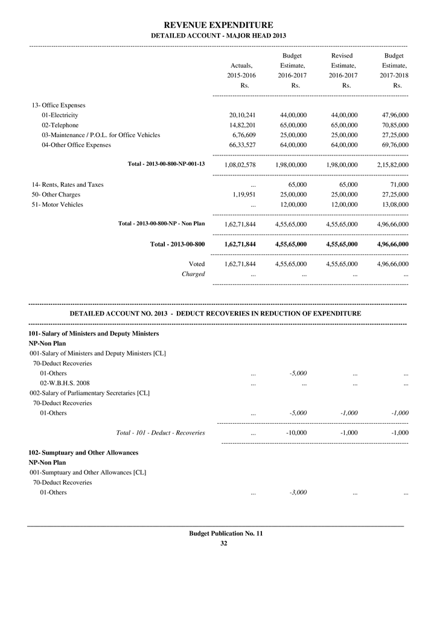

```python
Image('west_bengal_sample.png')
```

## Exercise: Sample 1

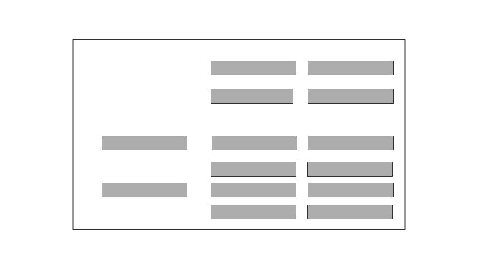

```python
Image('subject2.jpg')
```

## Exercise: Sample 2

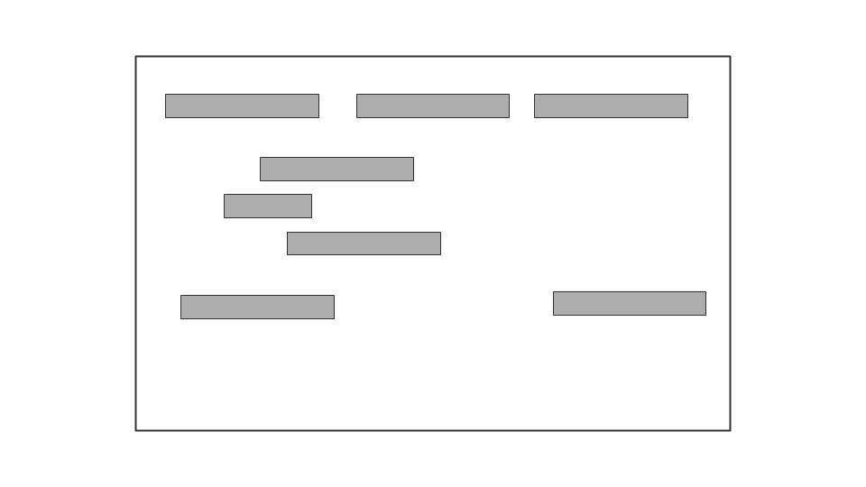

```python
Image('subject1.jpg')
```

## Exercise: Sample 3

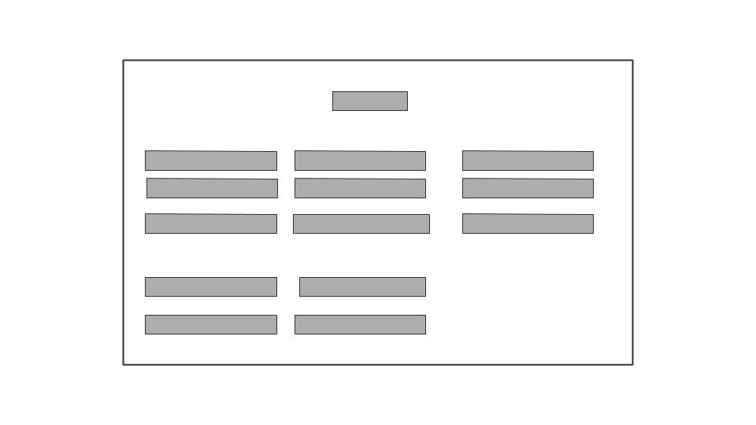

```python
Image('subject3.jpg')
```

## Extracting Geometrical features

- Extract Blocks from Page Image.
- Extract geometrical features of each block.

## Extract Blocks From Page Image

```
We use a modified version of the Run Length Smoothing Algorithm (RLSA)

RLSA convert a byte sequence `x` into `y` based on two rules : -

1. 0's in x are changed to 1 if their is 1 in the next C adjacent pixels.
2. 1's remain unchanged.

C here is a threshold
```

source: http://crblpocr.blogspot.in/2007/06/run-length-smoothing-algorithm-rlsa.html

## RLSA Image

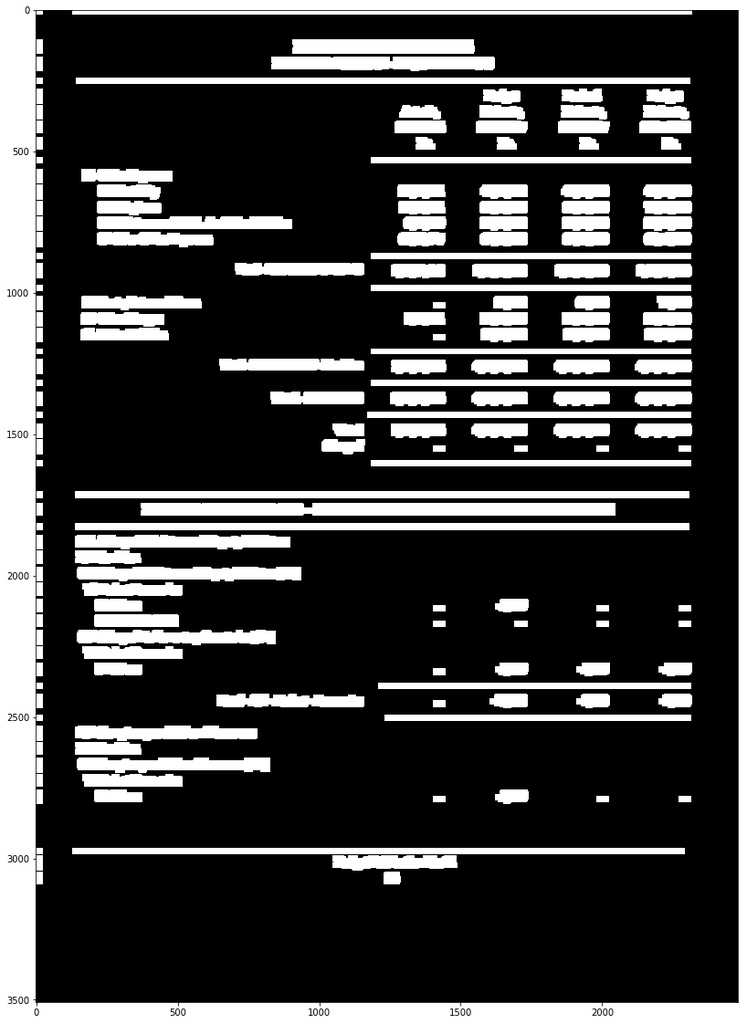

```python
threshold = (25, 20)
wb_image_rlsa = rlsa_2d(wb_page_image, threshold)
plot_page(wb_image_rlsa)
```

## Can we do better ?

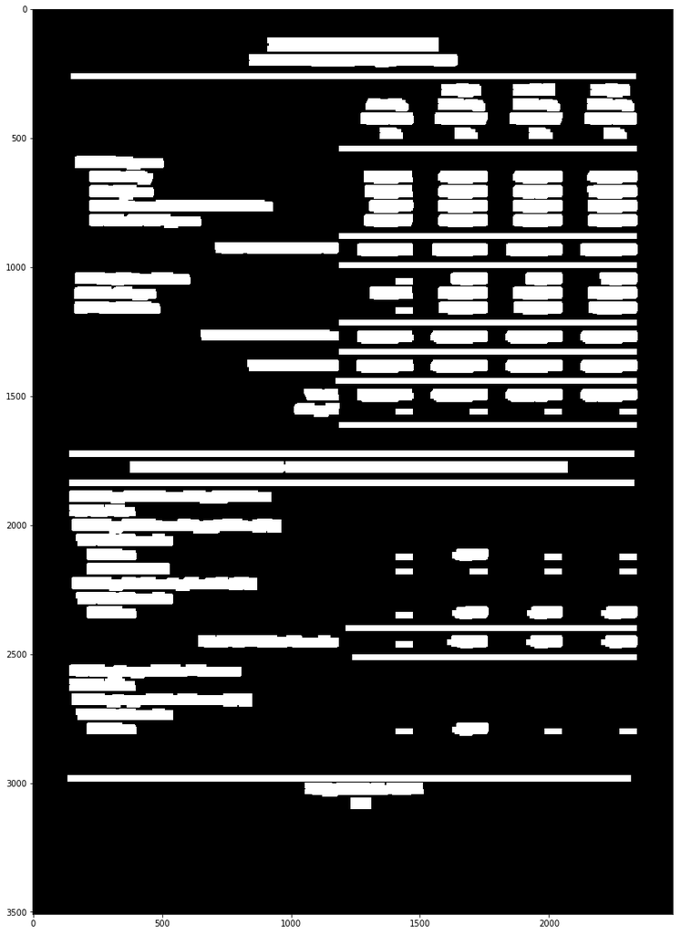

```python
def generate_blocks_dilation(img):
    kernel = np.ones((5,10),np.uint8)
    ret,thresh1 = cv2.threshold(img, 0, 1, cv2.THRESH_BINARY_INV)
    return cv2.dilate(thresh1,kernel,iterations = 5)

plot_page(generate_blocks_dilation(wb_page_image))
```

## Extracting Features Using OpenCV

```
Use cv2.connectedComponentsWithStats()
```

```python
import pandas as pd

n_comp, labels, stats, centroids = cv2.connectedComponentsWithStats(wb_image_rlsa)

block_stats = get_block_stats(stats, centroids)
block_stats['right'] = block_stats.left + block_stats.width
block_stats['bottom'] = block_stats.top + block_stats.height
block_stats.head(10)
```

|  | left | top | width | height | area | centroid_x | centroid_y | right | bottom |
| --- | --- | --- | --- | --- | --- | --- | --- | --- | --- |
| 1 | 0 | 0 | 25 | 20 | 500 | 12.000000 | 9.500000 | 25 | 20 |
| 2 | 130 | 0 | 2188 | 20 | 43760 | 1223.500000 | 9.500000 | 2318 | 20 |
| 3 | 0 | 105 | 25 | 54 | 1350 | 12.000000 | 131.500000 | 25 | 159 |
| 4 | 906 | 105 | 643 | 54 | 34128 | 1226.833304 | 131.129249 | 1549 | 159 |
| 5 | 0 | 169 | 25 | 49 | 1225 | 12.000000 | 193.000000 | 25 | 218 |
| 6 | 833 | 169 | 789 | 49 | 35613 | 1227.420240 | 191.262853 | 1622 | 218 |
| 7 | 0 | 242 | 25 | 22 | 550 | 12.000000 | 252.500000 | 25 | 264 |
| 8 | 143 | 242 | 2168 | 22 | 47696 | 1226.500000 | 252.500000 | 2311 | 264 |
| 9 | 0 | 282 | 25 | 54 | 1350 | 12.000000 | 308.500000 | 25 | 336 |
| 10 | 1579 | 282 | 133 | 54 | 5931 | 1644.686562 | 307.158827 | 1712 | 336 |

## Layout Analysis

Identifying the layout of the table, where the elements of the table are :-

- Header
- Values
- Empty Cells

## Reading Text From PDF

```
We use poppler's version of `pdftotext`
```

```python
def get_text(page_num, pdf_file_name, x, y, w, h):
    command_text = 'pdftotext -enc UTF-8  -f {0} -l {0} -x {1} -y {2} -W {3} -H {4} "{5}" -'
    command = command_text.format(page_num + 1, int(x),
                                  int(y), int(w),
                                  int(h), pdf_file_name)
    return subprocess.check_output(command, shell=True)
```

## Extracting Text based Features

```python
block_stats = block_stats.apply(get_text_data, axis=1, args=[33, wb_pdf_file_path, horizontal_ratio, vertical_ratio])
block_stats[block_stats.text_length > 0][text_columns].sample(5)
```

|  | text | text_length | comma_separated_numbers_present | is_text | number |
| --- | --- | --- | --- | --- | --- |
| 61 | 1,98,00,000 | 11 | False | False | 19800000.0 |
| 83 | ... | 3 | False | False | NaN |
| 91 | 4,96,66,000 | 11 | False | False | 49666000.0 |
| 159 | ... | 3 | False | False | NaN |
| 105 | 4,55,65,000 | 11 | False | False | 45565000.0 |

## Rule Based Marking

- Mark Numbers
- Mark Headers
- Mark Titles
- Mark Groupings

```python
block_stats[['text', 'label']].sample(10)
```

|  | text | label |
| --- | --- | --- |
| 137 | 02-W.B.H.S. 2008 | cell_grouping |
| 59 | Total - 2013-00-800-NP-001-13 | NaN |
| 103 | Voted | NaN |
| 24 | Rs. | NaN |
| 52 | 66,33,527 | cell_values |
| 68 | 65,000 | cell_values |
| 134 | ... | cell_values |
| 82 | 13,08,000 | cell_values |
| 145 | 70-Deduct Recoveries | NaN |
| 167 | 001-Sumptuary and Other Allowances [CL] | NaN |

[figure not shown]

```python
Image('rules.jpg')
```

## Moving from Rules to Machine Learning

### Generating Meta-Data via Logging

- Raw Images
- Blocked Images
- Features Generated
- Output

```python
block_stats.head()
```

|  | area | bottom | centroid_x | centroid_y | comma_separated_numbers_present | header_index | height | is_text | label | left | number | pos | possible_row_merger | right | text | text_length | top | width |
| --- | --- | --- | --- | --- | --- | --- | --- | --- | --- | --- | --- | --- | --- | --- | --- | --- | --- | --- |
| 4 | 34128.0 | 159.0 | 1226.833304 | 131.129249 | 0.0 | NaN | 54.0 | 1.0 | title | 906.0 | NaN | 4.0 | 0.0 | 1549.0 | REVENUE EXPENDITURE | 19.0 | 105.0 | 643.0 |
| 6 | 35613.0 | 218.0 | 1227.420240 | 191.262853 | 0.0 | NaN | 49.0 | 1.0 | title | 833.0 | NaN | 6.0 | 0.0 | 1622.0 | DETAILED ACCOUNT - MAJOR HEAD 2013 | 34.0 | 169.0 | 789.0 |
| 10 | 5931.0 | 336.0 | 1644.686562 | 307.158827 | 0.0 | NaN | 54.0 | 1.0 | NaN | 1579.0 | NaN | 10.0 | 0.0 | 1712.0 | Budget | 6.0 | 282.0 | 133.0 |
| 11 | 6180.0 | 328.0 | 1927.556472 | 305.665210 | 0.0 | NaN | 46.0 | 1.0 | NaN | 1856.0 | NaN | 11.0 | 0.0 | 2001.0 | Revised | 7.0 | 282.0 | 145.0 |
| 12 | 5931.0 | 336.0 | 2222.686562 | 307.158827 | 0.0 | NaN | 54.0 | 1.0 | NaN | 2157.0 | NaN | 12.0 | 0.0 | 2290.0 | Budget | 6.0 | 282.0 | 133.0 |

## Opportunities

- Bayesian Models to predict labels for each block.
- Recurrent Neural Nets to mark blocks.

```
Source: https://twitter.com/fatiichi/status/466398802476548096
```

[figure not shown]

```python
print('Source: https://twitter.com/fatiichi/status/466398802476548096')
Image('googly_eyes.jpg')
```

## Open By Default - Open Research

- Reproducable
- Understandable
- Collaborative

## Contribute

### Help us to:

- Generate more Open Budget Data
- Improve our Algorithms & Codebase
- Cover Budget Data in your Geography
- Refine our Designs & much more!

### We are open to new ideas, suggestions and feedback

# Open For Questions

# Thank You

## Github: https://github.com/cbgaindia

[figure not shown]

```python
Image('static_qr_code_without_logo.jpg')
```